# Lecture 3

562770bf

2024-11-14

This is the Rmd file for the Data Science and HR analytics course, trying out experiments on the code for lecture 3.

So let’s get started.

```r
oj <- read.csv("/Users/annelies2/Downloads/oj.csv")
head(oj, n=5)
```

```
##   sales price     brand feat
## 1  8256  3.87 tropicana    0
## 2  6144  3.87 tropicana    0
## 3  3840  3.87 tropicana    0
## 4  8000  3.87 tropicana    0
## 5  8896  3.87 tropicana    0
```

```r
tail(oj, n=5)
```

```
##       sales price     brand feat
## 28943  2944  2.00 dominicks    0
## 28944  4928  1.94 dominicks    0
## 28945 13440  1.59 dominicks    0
## 28946 55680  1.49 dominicks    0
## 28947  7040  1.75 dominicks    0
```

```r
glm(log(sales) ~ brand + log(price), data=oj)
```

```
##
## Call:  glm(formula = log(sales) ~ brand + log(price), data = oj)
##
## Coefficients:
##      (Intercept)  brandminute.maid    brandtropicana        log(price)
##          10.8288            0.8702            1.5299           -3.1387
##
## Degrees of Freedom: 28946 Total (i.e. Null);  28943 Residual
## Null Deviance:       30080
## Residual Deviance: 18220     AIC: 68760
```

The code starts by loading a CSV file from a specified location into a data frame called `oj`. It then shows the first five rows of the data with `head()`, giving a quick glimpse of the beginning of the dataset, and uses `tail()` to display the last five rows for a sense of the data’s conclusion. Finally, it runs a regression (GLM) to examine how the log of sales is influenced by brand and the log of price, with these two factors acting as predictors. This helps to understand the relationship between the sales, brand, and price in the dataset.

```r
x <- model.matrix(~ brand + log(price), data=oj); head(x); tail(x)
```

```
##   (Intercept) brandminute.maid brandtropicana log(price)
## 1           1                0              1   1.353255
## 2           1                0              1   1.353255
## 3           1                0              1   1.353255
## 4           1                0              1   1.353255
## 5           1                0              1   1.353255
## 6           1                0              1   1.353255
```

```
##       (Intercept) brandminute.maid brandtropicana log(price)
## 28942           1                0              0  0.2700271
## 28943           1                0              0  0.6931472
## 28944           1                0              0  0.6626880
## 28945           1                0              0  0.4637340
## 28946           1                0              0  0.3987761
## 28947           1                0              0  0.5596158
```

```r
oj$brand = as.factor(oj$brand)
x <- model.matrix(~ brand + log(price), data=oj); head(x)
```

```
##   (Intercept) brandminute.maid brandtropicana log(price)
## 1           1                0              1   1.353255
## 2           1                0              1   1.353255
## 3           1                0              1   1.353255
## 4           1                0              1   1.353255
## 5           1                0              1   1.353255
## 6           1                0              1   1.353255
```

```r
oj$mybrand = relevel(oj$brand, "tropicana")
x <- model.matrix(~ mybrand + log(price), data=oj); head(x)
```

```
##   (Intercept) mybranddominicks mybrandminute.maid log(price)
## 1           1                0                  0   1.353255
## 2           1                0                  0   1.353255
## 3           1                0                  0   1.353255
## 4           1                0                  0   1.353255
## 5           1                0                  0   1.353255
## 6           1                0                  0   1.353255
```

```r
glm(log(sales) ~ log(price)*brand*feat, data=oj)
```

```
##
## Call:  glm(formula = log(sales) ~ log(price) * brand * feat, data = oj)
##
## Coefficients:
##                      (Intercept)                        log(price)
##                          10.4066                           -2.7742
##                 brandminute.maid                    brandtropicana
##                           0.0472                            0.7079
##                             feat       log(price):brandminute.maid
##                           1.0944                            0.7829
##        log(price):brandtropicana                   log(price):feat
##                           0.7358                           -0.4706
##            brandminute.maid:feat               brandtropicana:feat
##                           1.1729                            0.7853
## log(price):brandminute.maid:feat    log(price):brandtropicana:feat
##                          -1.1092                           -0.9861
##
## Degrees of Freedom: 28946 Total (i.e. Null);  28935 Residual
## Null Deviance:       30080
## Residual Deviance: 13970     AIC: 61090
```

This code first creates a design matrix `x` for the predictors `brand` and `log(price)` in the `oj` dataset, showing the matrix form of these variables. It then relevels the `brand` variable by setting “tropicana” as the reference level and creates a new design matrix `x` based on this releveling. Finally, the code fits a generalized linear model (GLM) to predict `log(sales)` based on the interaction of `log(price)`, `brand`, and `feat` (features).

```r
#Experiment
oj$brand = as.factor(oj$brand)
# Fit a GLM model without interaction term
model_no_interaction <- glm(log(sales) ~ log(price) + brand, data=oj)
summary(model_no_interaction)
```

```
##
## Call:
## glm(formula = log(sales) ~ log(price) + brand, data = oj)
##
## Coefficients:
##                  Estimate Std. Error t value Pr(>|t|)
## (Intercept)      10.82882    0.01453  745.04   <2e-16 ***
## log(price)       -3.13869    0.02293 -136.89   <2e-16 ***
## brandminute.maid  0.87017    0.01293   67.32   <2e-16 ***
## brandtropicana    1.52994    0.01631   93.81   <2e-16 ***
## ---
## Signif. codes:  0 '***' 0.001 '**' 0.01 '*' 0.05 '.' 0.1 ' ' 1
##
## (Dispersion parameter for gaussian family taken to be 0.6296804)
##
##     Null deviance: 30079  on 28946  degrees of freedom
## Residual deviance: 18225  on 28943  degrees of freedom
## AIC: 68765
##
## Number of Fisher Scoring iterations: 2
```

```r
# Fit a GLM model with interaction term
model_with_interaction <- glm(log(sales) ~ log(price) * brand, data=oj)
summary(model_with_interaction)
```

```
##
## Call:
## glm(formula = log(sales) ~ log(price) * brand, data = oj)
##
## Coefficients:
##                             Estimate Std. Error t value Pr(>|t|)
## (Intercept)                 10.95468    0.02070 529.136   <2e-16 ***
## log(price)                  -3.37753    0.03619 -93.322   <2e-16 ***
## brandminute.maid             0.88825    0.04155  21.376   <2e-16 ***
## brandtropicana               0.96239    0.04645  20.719   <2e-16 ***
## log(price):brandminute.maid  0.05679    0.05729   0.991    0.322
## log(price):brandtropicana    0.66576    0.05352  12.439   <2e-16 ***
## ---
## Signif. codes:  0 '***' 0.001 '**' 0.01 '*' 0.05 '.' 0.1 ' ' 1
##
## (Dispersion parameter for gaussian family taken to be 0.6258833)
##
##     Null deviance: 30079  on 28946  degrees of freedom
## Residual deviance: 18114  on 28941  degrees of freedom
## AIC: 68592
##
## Number of Fisher Scoring iterations: 2
```

```r
# Compare AIC (Akaike Information Criterion) to evaluate the model performance
AIC(model_no_interaction, model_with_interaction)
```

```
##                        df      AIC
## model_no_interaction    5 68764.80
## model_with_interaction  7 68591.71
```

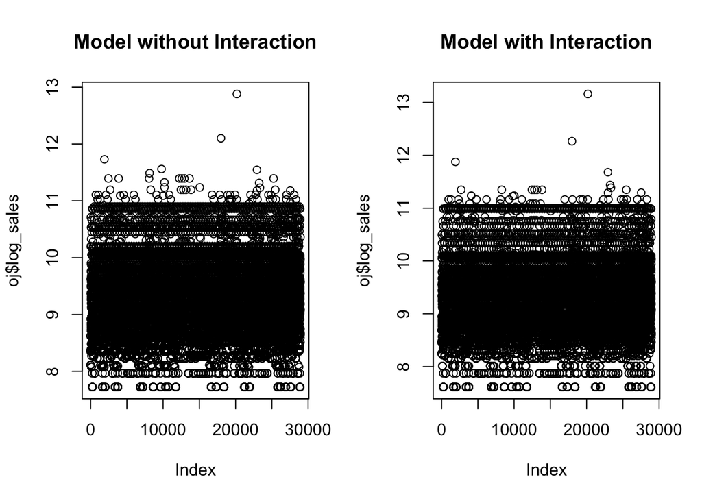

```r
# Plot the results
par(mfrow = c(1, 2))
plot(model_no_interaction$fitted.values, oj$log_sales, main = "Model without Interaction")
plot(model_with_interaction$fitted.values, oj$log_sales, main = "Model with Interaction")
```

```r
email <- read.csv("/Users/annelies2/Downloads/spam.csv")
dim(email)
```

```
## [1] 4601   58
```

```r
colnames(email)
```

```
##  [1] "word_make"                  "word_address"
##  [3] "word_all"                   "word_3d"
##  [5] "word_our"                   "word_over"
##  [7] "word_remove"                "word_internet"
##  [9] "word_order"                 "word_mail"
## [11] "word_receive"               "word_will"
## [13] "word_people"                "word_report"
## [15] "word_addresses"             "word_free"
## [17] "word_business"              "word_email"
## [19] "word_you"                   "word_credit"
## [21] "word_your"                  "word_font"
## [23] "word_000"                   "word_money"
## [25] "word_hp"                    "word_hpl"
## [27] "word_george"                "word_650"
## [29] "word_lab"                   "word_labs"
## [31] "word_telnet"                "word_857"
## [33] "word_data"                  "word_415"
## [35] "word_85"                    "word_technology"
## [37] "word_1999"                  "word_parts"
## [39] "word_pm"                    "word_direct"
## [41] "word_cs"                    "word_meeting"
## [43] "word_original"              "word_project"
## [45] "word_re"                    "word_edu"
## [47] "word_table"                 "word_conference"
## [49] "char_semicolon"             "char_leftbrac"
## [51] "char_leftsquarebrac"        "char_exclaim"
## [53] "char_dollar"                "char_pound"
## [55] "capital_run_length_average" "capital_run_length_longest"
## [57] "capital_run_length_total"   "spam"
```

```r
glm(spam ~ ., data=email, family='binomial')
```

```
##
## Call:  glm(formula = spam ~ ., family = "binomial", data = email)
##
## Coefficients:
##                (Intercept)                   word_make
##                 -1.9682470                  -0.5529572
##               word_address                    word_all
##                 -0.1338696                  -0.4946420
##                    word_3d                    word_our
##                  0.8301668                   1.1252843
##                  word_over                 word_remove
##                  0.2750951                   2.4881234
##              word_internet                  word_order
##                  0.9333968                   0.2196402
##                  word_mail                word_receive
##                  0.3081450                  -0.4391531
##                  word_will                 word_people
##                 -0.3105941                  -0.9585867
##                word_report              word_addresses
##                  0.8466587                   1.2553331
##                  word_free               word_business
##                  1.5427059                   1.0566330
##                 word_email                    word_you
##                 -0.5200992                   0.1628054
##                word_credit                   word_your
##                  0.4160407                   0.6949764
##                  word_font                    word_000
##                  1.2999227                   1.0349534
##                 word_money                     word_hp
##                  1.7300810                  -3.6043950
##                   word_hpl                 word_george
##                 -0.1806108                  -5.7798414
##                   word_650                    word_lab
##                  2.1047235                  -0.6635103
##                  word_labs                 word_telnet
##                 -0.1804292                  -2.3018083
##                   word_857                   word_data
##                 -1.4454869                  -0.7849383
##                   word_415                     word_85
##                  0.9195251                  -1.7312335
```

[output cut: 11 more lines]

```
##                 -2.4268251                   0.2853855
##            word_conference              char_semicolon
##                 -2.2234335                  -0.2928835
##              char_leftbrac         char_leftsquarebrac
##                  0.1256978                  -0.3345468
##               char_exclaim                 char_dollar
##                  1.3427284                   1.8707164
##                 char_pound  capital_run_length_average
##                 -0.8186884                  -0.0031379
## capital_run_length_longest    capital_run_length_total
##                  0.0060448                   0.0008344
##
## Degrees of Freedom: 4600 Total (i.e. Null);  4543 Residual
## Null Deviance:       6170
## Residual Deviance: 1549  AIC: 1665
```

This code reads in a dataset called “spam.csv”, checks its dimensions and column names, and then fits a logistic regression model (binomial family) to predict whether an email is spam using all the variables in the dataset.

```r
#Experiment
# Assuming 'free' and 'money' are columns representing the presence of these words
email <- read.csv("/Users/annelies2/Downloads/spam.csv")
model <- glm(spam ~ word_free * word_money, data=email, family='binomial')
summary(model)
```

```
##
## Call:
## glm(formula = spam ~ word_free * word_money, family = "binomial",
##     data = email)
##
## Coefficients:
##                      Estimate Std. Error z value Pr(>|z|)
## (Intercept)          -1.46142    0.04609 -31.710  < 2e-16 ***
## word_free             2.32393    0.09071  25.621  < 2e-16 ***
## word_money            3.40324    0.18653  18.245  < 2e-16 ***
## word_free:word_money -1.13025    0.30951  -3.652  0.00026 ***
## ---
## Signif. codes:  0 '***' 0.001 '**' 0.01 '*' 0.05 '.' 0.1 ' ' 1
##
## (Dispersion parameter for binomial family taken to be 1)
##
##     Null deviance: 6170.2  on 4600  degrees of freedom
## Residual deviance: 4303.9  on 4597  degrees of freedom
## AIC: 4311.9
##
## Number of Fisher Scoring iterations: 5
```

From this experiment, you may learn which combinations of words increase the probability of an email being classified as spam, helping refine spam detection models.

```r
email <- read.csv("/Users/annelies2/Downloads/spam.csv")
spammy <- glm(spam ~ ., data=email, family='binomial')
coef(spammy)["word_free"];exp(coef(spammy)["word_free"])
```

```
## word_free
##  1.542706
```

```
## word_free
##  4.677229
```

```r
coef(spammy)["word_george"]; exp(coef(spammy)["word_george"]); 1/exp(coef(spammy)["word_george"])
```

```
## word_george
##   -5.779841
```

```
## word_george
## 0.003089205
```

```
## word_george
##    323.7078
```

This code loads a dataset (spam.csv) into the email variable. Fits a logistic regression model (spammy) to predict whether an email is spam based on its features (all columns except for the target variable spam). Extracts the coefficient for the term word_free and calculates its odds ratio by exponentiating the coefficient. Does the same for the term word_george, showing both the coefficient and the odds ratio. It also computes the inverse of the odds ratio for word_george.

```r
#Experiment
spammy_interaction <- glm(spam ~ word_free * word_george, data=email, family='binomial')
coef(spammy_interaction)
```

```
##           (Intercept)             word_free           word_george
##            -0.7999772             2.3983542            -3.6998325
## word_free:word_george
##           -13.4646127
```

```r
exp(coef(spammy_interaction))
```

```
##           (Intercept)             word_free           word_george
##          4.493392e-01          1.100505e+01          2.472767e-02
## word_free:word_george
##          1.420342e-06
```

By adding interaction terms (e.g., word_free * word_george), we can test whether the combination of specific words increases the likelihood of an email being marked as spam. The odds ratio for an interaction term will give us insight into how the combination of these two words affects the probability of spam.

```r
predict(spammy, newdata = email[c(1,4000),], type="response")
```

```
##         1      4000
## 0.8839073 0.1509989
```

This code uses the fitted logistic regression model spammy to predict the probability that the first and 4000th emails in the dataset are spam. It uses the type=“response” argument to return the predicted probabilities, which is the likelihood that each email is spam, rather than just the log-odds.

```r
#Experiment
set.seed(123)
sample_emails <- sample(1:nrow(email), 5)
predictions <- predict(spammy, newdata = email[sample_emails,], type="response")
predictions
```

```
##         2463         2511         2227          526         4291
## 0.0005696853 0.2491059772 0.0169288984 0.9973181871 0.0568483027
```

This experiment predicts the probability of spam for five random emails. From the results, I learned that the model can give varying probabilities for spam based on the words used in the email. A higher probability means the email is more likely to be spam according to the model, and we can use this information to classify emails more effectively.

```r
summary(spammy)$deviance
```

```
## [1] 1548.66
```

```r
summary(spammy)$null.deviance
```

```
## [1] 6170.153
```

The code summary(spammy) deviance retrieves the deviance of the fitted logistic regression model, which measures the goodness of fit. A lower deviance value indicates a better model fit to the data. summary(spammy) null.deviance gives the deviance of a null model, which is a model with no predictors—just an intercept. The comparison of these two values can help us assess the improvement in model fit due to the predictors in the model.

Deviance (1548.66): This is the deviance of the fitted model, which quantifies how well the model fits the data. It’s based on the likelihood of the model. A lower deviance indicates a better fit, as it means the model’s predictions are closer to the observed values. Null Deviance (6170.153): This is the deviance of the null model, which includes no predictors (just an intercept). It represents how well the model would perform if we predicted the outcome with just the average value (i.e., without considering any explanatory variables).

```r
D <- summary(spammy)$deviance; D
```

```
## [1] 1548.66
```

```r
D0 <- summary(spammy)$null.deviance; D0
```

```
## [1] 6170.153
```

```r
R2 <- 1 - D/D0; R2
```

```
## [1] 0.7490079
```

The code gives the McFadden’s R² value, which is a measure of the model’s goodness of fit.